# Individual2

```r
library(readxl)
library(ggplot2)
library(tidyverse)
library(dplyr)
dat <- readxl::read_xls('./GSS.xls')
str(dat)
```

```
## tibble [64,816 x 7] (S3: tbl_df/tbl/data.frame)
##  $ Marital status                  : chr [1:64816] "Never married" "Married" "Married" "Married" ...
##  $ Age of respondent               : chr [1:64816] "23" "70" "48" "27" ...
##  $ Highest year of school completed: chr [1:64816] "16" "10" "12" "17" ...
##  $ Respondents sex                 : chr [1:64816] "Female" "Male" "Female" "Female" ...
##  $ Race of respondent              : chr [1:64816] "White" "White" "White" "White" ...
##  $ Political party affiliation     : chr [1:64816] "Ind,near dem" "Not str democrat" "Independent" "Not str democrat" ...
##  $ General happiness               : chr [1:64816] "Not too happy" "Not too happy" "Pretty happy" "Not too happy" ...
```

# Replacing spaces with a “.” in column names so we can rename later

```r
names(dat) <- str_replace_all(names(dat), c(" " = "."))
str(dat)
```

```
## tibble [64,816 x 7] (S3: tbl_df/tbl/data.frame)
##  $ Marital.status                  : chr [1:64816] "Never married" "Married" "Married" "Married" ...
##  $ Age.of.respondent               : chr [1:64816] "23" "70" "48" "27" ...
##  $ Highest.year.of.school.completed: chr [1:64816] "16" "10" "12" "17" ...
##  $ Respondents.sex                 : chr [1:64816] "Female" "Male" "Female" "Female" ...
##  $ Race.of.respondent              : chr [1:64816] "White" "White" "White" "White" ...
##  $ Political.party.affiliation     : chr [1:64816] "Ind,near dem" "Not str democrat" "Independent" "Not str democrat" ...
##  $ General.happiness               : chr [1:64816] "Not too happy" "Not too happy" "Pretty happy" "Not too happy" ...
```

# Renaming column names for easier use

```r
dat <- rename(dat,"Age" = Age.of.respondent, "Education" = Highest.year.of.school.completed, "Sex" = Respondents.sex, "Race" = Race.of.respondent, "Party" = Political.party.affiliation, "Happiness" = General.happiness)
head(dat)
```

```
## # A tibble: 6 x 7
##   Marital.status Age   Education Sex    Race  Party            Happiness
##   <chr>          <chr> <chr>     <chr>  <chr> <chr>            <chr>
## 1 Never married  23    16        Female White Ind,near dem     Not too happy
## 2 Married        70    10        Male   White Not str democrat Not too happy
## 3 Married        48    12        Female White Independent      Pretty happy
## 4 Married        27    17        Female White Not str democrat Not too happy
## 5 Married        61    12        Female White Strong democrat  Pretty happy
## 6 Never married  26    14        Male   White Ind,near dem     Pretty happy
```

# More Cleaning

```r
dat <- dat %>%
  mutate(Age = as.numeric(Age), Education = as.numeric(Education))
head(dat)
```

```
## # A tibble: 6 x 7
##   Marital.status   Age Education Sex    Race  Party            Happiness
##   <chr>          <dbl>     <dbl> <chr>  <chr> <chr>            <chr>
## 1 Never married     23        16 Female White Ind,near dem     Not too happy
## 2 Married           70        10 Male   White Not str democrat Not too happy
## 3 Married           48        12 Female White Independent      Pretty happy
## 4 Married           27        17 Female White Not str democrat Not too happy
## 5 Married           61        12 Female White Strong democrat  Pretty happy
## 6 Never married     26        14 Male   White Ind,near dem     Pretty happy
```

## Question 1

```r
Educ <- dat[c('Party', 'Education')]
Educ <- filter(Educ, Educ$Education != 'No answer')
Educ <- filter(Educ, Educ$Education != 'Dont know')
Educ <- aggregate(Educ$Education, list(Educ$Party), FUN = mean)
Educ
```

```
##               Group.1        x
## 1          Don't know 10.90909
## 2        Ind,near dem 13.20671
## 3        Ind,near rep 13.29531
## 4         Independent 12.31946
## 5           No answer 12.27913
## 6    Not str democrat 12.61759
## 7  Not str republican 13.25678
## 8         Other party 13.43324
## 9     Strong democrat 12.47403
## 10  Strong republican 13.44067
```

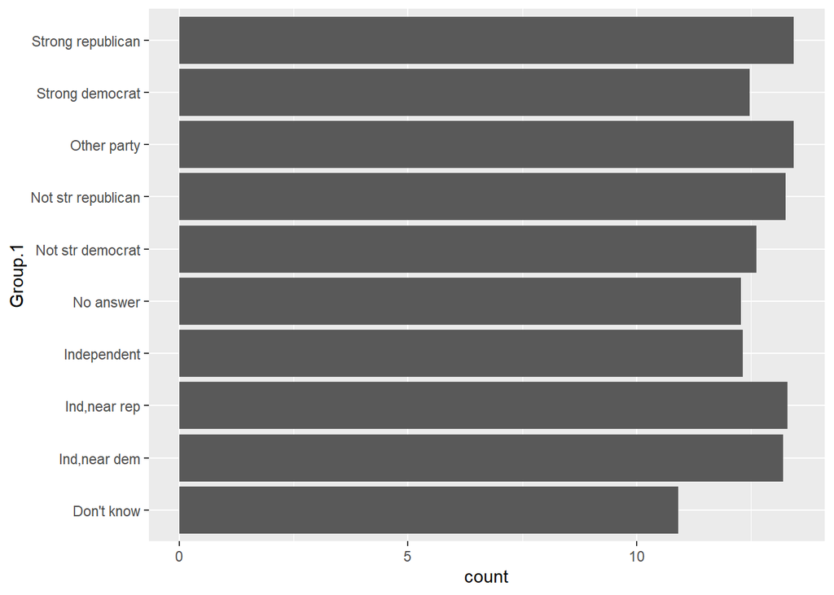

```r
ggplot(Educ, aes(x = Group.1, weight = x)) + geom_bar() + coord_flip()
```

Through further investigation, I can declare that the most educated people are Strong Republicans. On the other hand, Strong Democrats did not seem to have as much education compared to Republicans.The Independent category seemed to have less education compared to both Republicans and Democrats. Lastly, people who do not know their political party affiliation have the lowest amount of education.

## Question 2

```r
Educated <- dat %>%
  select(Party, Education) %>%
  drop_na %>%
  group_by(Party) %>%
  mutate(Education - as.numeric(Education, na.rm = TRUE)) %>%
  filter(Education > median(Education, na.rm = TRUE))
str(Educated)
```

```
## tibble [27,840 x 3] (S3: grouped_df/tbl_df/tbl/data.frame)
##  $ Party                                          : chr [1:27840] "Ind,near dem" "Not str democrat" "Ind,near dem" "Ind,near dem" ...
##  $ Education                                      : num [1:27840] 16 17 14 16 13 14 14 17 14 16 ...
##  $ Education - as.numeric(Education, na.rm = TRUE): num [1:27840] 0 0 0 0 0 0 0 0 0 0 ...
##  - attr(*, "groups")= tibble [10 x 2] (S3: tbl_df/tbl/data.frame)
##   ..$ Party: chr [1:10] "Don't know" "Ind,near dem" "Ind,near rep" "Independent" ...
##   ..$ .rows: list<int> [1:10]
##   .. ..$ : int [1:5] 837 1083 1137 1262 23661
##   .. ..$ : int [1:3257] 1 3 4 8 16 19 27 35 41 47 ...
##   .. ..$ : int [1:2456] 7 9 11 21 43 53 56 58 59 68 ...
##   .. ..$ : int [1:3852] 23 29 45 48 49 57 62 78 79 102 ...
##   .. ..$ : int [1:148] 299 519 689 897 1007 1102 1191 1482 1513 1648 ...
##   .. ..$ : int [1:5692] 2 13 15 25 28 31 36 38 44 46 ...
##   .. ..$ : int [1:4322] 14 18 20 24 30 33 42 52 65 71 ...
##   .. ..$ : int [1:520] 22 26 61 89 99 111 151 154 192 376 ...
##   .. ..$ : int [1:4537] 5 6 12 17 37 39 40 74 75 76 ...
##   .. ..$ : int [1:3051] 10 32 34 50 51 64 66 88 100 127 ...
##   .. ..@ ptype: int(0)
##   ..- attr(*, ".drop")= logi TRUE
```

## Question 3

```r
Question_Three <- dat %>%
  select(Happiness, Marital.status) %>%
  drop_na %>%
  filter(Marital.status != 'No Answer' & Marital.status != 'No answer' & Happiness != 'Dont know' & Happiness != 'No answer' & Happiness != 'Not applicable') %>%
  mutate(Marital.status = factor(Marital.status, levels = c('Never married', 'Divorced', 'Seperated', 'Widowed', 'Married'))) %>%
  arrange(Marital.status)
summary(Question_Three)
```

```
##   Happiness               Marital.status
##  Length:60072       Never married:12751
##  Class :character   Divorced     : 7633
##  Mode  :character   Seperated    :    0
##                     Widowed      : 5821
##                     Married      :31785
##                     NA's         : 2082
```

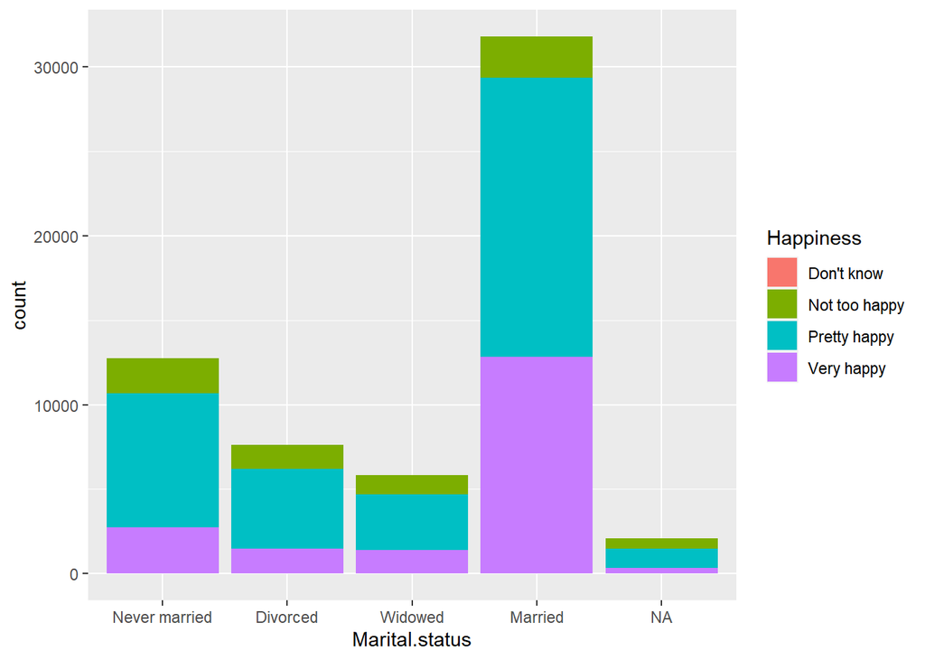

```r
ggplot(Question_Three, aes(x=Marital.status, fill=Happiness)) + geom_bar()
```

I would add something here discussing how the happiest people both in number of happy respondents and (more importantly) in the proportion of very happy and pretty happy to not too happy was married people.

## Question 4

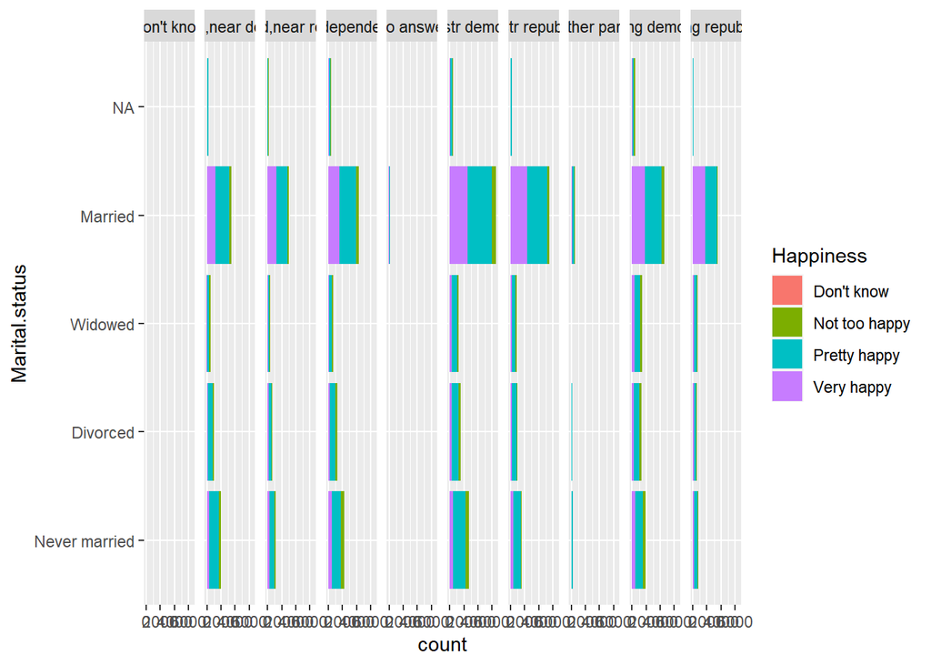

```r
Q4 <- dat %>%
  select(Happiness, Marital.status, Party) %>%
  drop_na %>%
  filter(Marital.status != "No Answer" & Marital.status != 'No answer' &  Happiness != 'Dont know' & Happiness != 'No answer' & Happiness != 'Not applicable') %>%
  mutate(Marital.status = factor(Marital.status, levels = c('Never married', 'Divorced', 'Seperated', 'Widowed', 'Married'))) %>%
  arrange(Marital.status)



ggplot(Q4, aes(x=Marital.status, fill=Happiness)) + geom_bar() + facet_grid(~Party) + coord_flip()
```

There seems to be more Married people that are very happy while having a political affiliation of either not str democrat or not str republican. The same can be said for married people who are a Strong Democrat or a Strong Republican.

## Question 5

```r
marriage.Seducation <- dat %>%
  select(Education, Marital.status) %>%
  drop_na %>%
  filter(Marital.status != 'No Answer' & Marital.status != 'No answer') %>%
  mutate(Marital.status = factor(Marital.status, levels = c('Never married', 'Divorced', 'Seperated', 'Widowed', 'Married'))) %>%
  arrange(Marital.status)
summary(marriage.Seducation)
```

```
##    Education           Marital.status
##  Min.   : 0.00   Never married:13801
##  1st Qu.:12.00   Divorced     : 8363
##  Median :12.00   Seperated    :    0
##  Mean   :12.87   Widowed      : 6164
##  3rd Qu.:15.00   Married      :34053
##  Max.   :20.00   NA's         : 2233
```

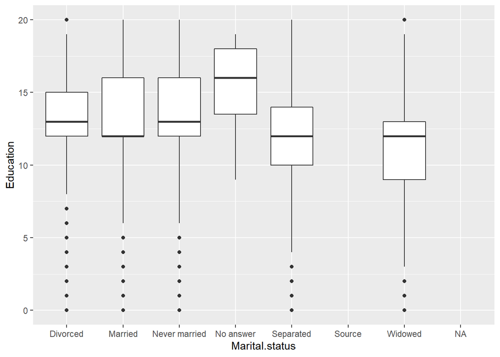

```r
ggplot(dat, aes(x = Marital.status, y = Education)) + geom_boxplot()
```

I would add something here about how widowed people are the least educated and come up with a hypothesis such as: widowed people are likely old and during their primary years of formal education a lot was different and people didn’t often get as many years of education as they do now.

## Question 6

```r
Q6 <- dat %>%
  select(Happiness, Race) %>%
  drop_na %>%
  filter(Race != 'No Answer' & Race != 'Dont know' & Happiness != 'Dont know' & Happiness != 'No answer' & Happiness != 'Not applicable') %>%
  mutate(Race = factor(Race, levels = c('White', 'Black', 'Other'))) %>%
  arrange(Race)
str(Q6)
```

```
## tibble [60,093 x 2] (S3: tbl_df/tbl/data.frame)
##  $ Happiness: chr [1:60093] "Not too happy" "Not too happy" "Pretty happy" "Not too happy" ...
##  $ Race     : Factor w/ 3 levels "White","Black",..: 1 1 1 1 1 1 1 1 1 1 ...
```

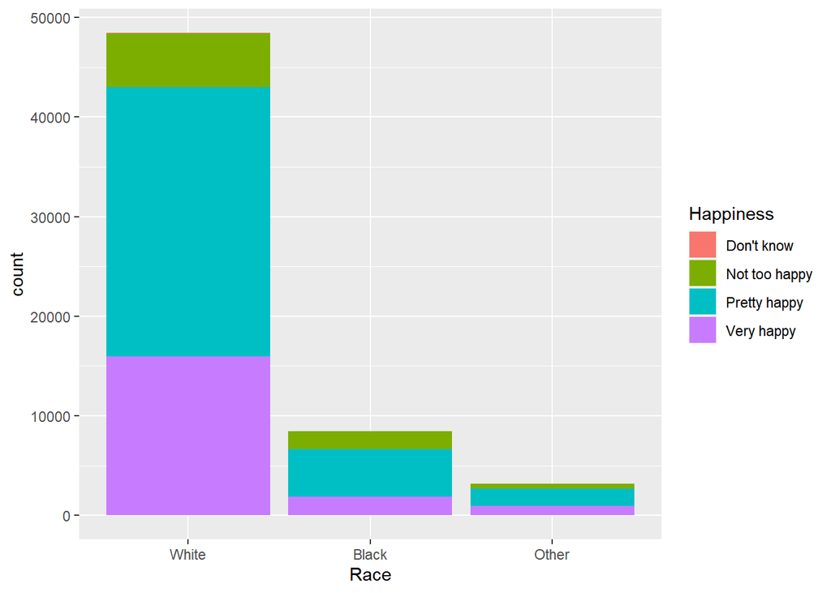

```r
ggplot(Q6, aes(x = Race, fill=Happiness)) + geom_bar()
```

```r
Age.Happiness <- dat %>%
  select(Happiness, Age) %>%
  drop_na %>%
  filter(Happiness != 'Dont know' & Happiness != 'No answer' & Happiness != 'Not applicable') %>%
  arrange(Age)
summary(Age.Happiness)
```

```
##   Happiness              Age
##  Length:59561       Min.   :18.00
##  Class :character   1st Qu.:31.00
##  Mode  :character   Median :43.00
##                     Mean   :45.83
##                     3rd Qu.:59.00
##                     Max.   :88.00
```

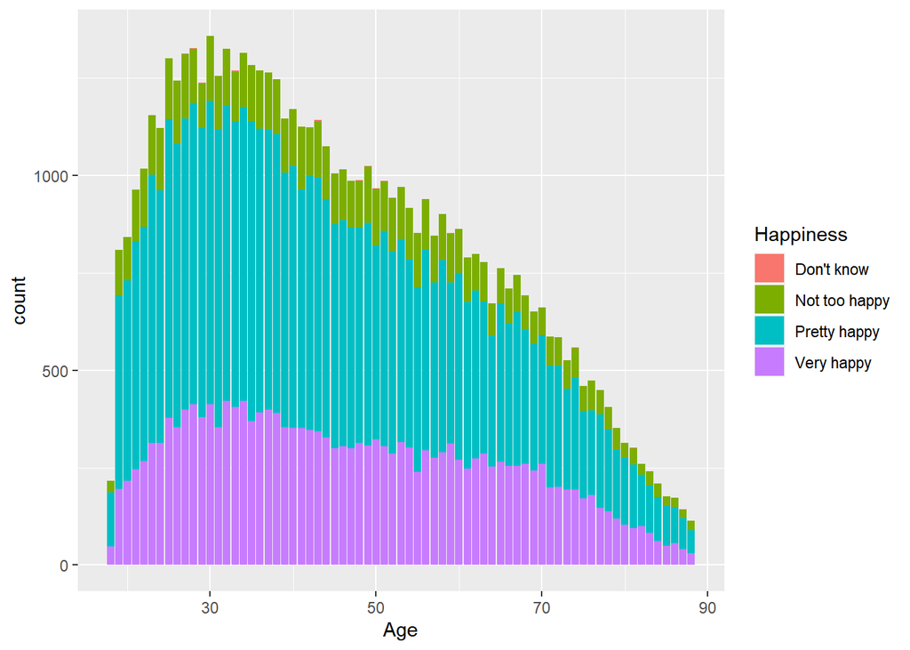

```r
ggplot(Age.Happiness, aes(x = Age, fill = Happiness)) + geom_bar()
```

This bar chart shows the decline in happiness as you get older. There is a spike of people being the happiest when they are in their 20s and 30s, but they slowly get less happier as they age. I would note that this chart shows more of a decline in respondents as people get older rather than a decline in happiness level. Looking at the proportions of respondents that selected each happiness level at each age is a better indication, which can still be seen from the graph somewhat. The older age groups have a larger proportion that is not too happy.